# Problem 3: Transformation from a Uniform Distribution

The Box-Muller transform is a popular sampling method for generating pairs of independent standard, normally distributed random variables from a pair of independent, standard uniformly distributed random numbers.

Specifically, Let $U_1 \sim Uniform(0, 1)$ and $U_2 \sim Uniform(0, 1)$ and define the random variables:

$$ \Theta = 2\pi U_1 $$$$ R = \sqrt{-2 \ln (U_2)} $$

Show that the random variable vector

$$ Z = \begin{pmatrix} R \cos(\Theta)\\ R \sin(\Theta) \end{pmatrix} $$

follows a standard bivariate normal distribution (i.e. $Z \sim \mathcal{N}(0, I_2)$).

Then, create a plot to verify that the transformed distribution is indeed Gaussian. You should start with `np.random.rand()` to sample from a uniform distribution.

## Solution

Suppose Z is the random vector

$$ Z = \begin{pmatrix} X \\ Y \end{pmatrix} $$

where $X = R \cos (\Theta)$ and $Y = R \sin (\Theta)$, which is literally just a point in 2D Cartesian space, that is represented in polar coordinates.

The goal is to show that the Joint Probability Density Function (PDF) $f_{X, Y}(x, y)$ produced by a Box Muller Transform is the exact same as the PDF of the standard bivariate normal distribution. Let's derive both.

The Covariance matrix is given as the identity matrix $$ I_2 = \begin{pmatrix} 1 & 0 \\ 0 & 1 \end{pmatrix} $$

which means that $X$ and $Y$ and independent. So the joint probability density function is defined as

$$ \begin{equation} f_{X, Y} (x, y) = \frac{1}{2 \pi} e^{-\frac{(x^2 + y^2)}{2}} \end{equation} $$

So now we just have to show that the PDF resulting from the Box-Muller Transform is exactly that. So what is $f_{\Theta, R} (\theta, r)$, the polar version of $f_{X, Y} (x, y)$?

Since $U_1$ and $U_2$ are independent by assumption, $R$ and $\Theta$ must be independent because $\Theta = f(U_1)$ and $R = g(U_2)$, they are just some functions of the two variables. So

$$ f_{\Theta, R} (\theta, r) = f_{\Theta}(\theta) f_{R}(r) $$

by the definition of independence for joint probability distributions.

We know that $U_1 \sim Uniform(0, 1)$, so that $\Theta = 2 \pi U_1$ must be $\Theta \sim Uniform(0, 2 \pi)$, so its pdf is

$$ f_{\Theta} (\theta) = \begin{cases} \frac{1}{2 \pi} & 0 \leq \theta < 2 \pi \\ 0 & \text{otherwise} \end{cases} $$

For $R = \sqrt{-2 \ln U_2}$, we can compute the CDF for $R$ and from there derive the pdf.

$$ \begin{align*} F_R (r) &= P(R \leq r)\\ &= P(\sqrt{-2 \ln U_2} \leq r)\\ &= P(-2 \ln U_2 \leq r^2)\\ &= P(2 \ln U_2 \geq -r^2)\\ &= P(\ln U_2 \geq \frac{-r^2}{2})\\ &= P(U_2 \geq e^{\frac{-r^2}{2}})\\ &= 1- P(U_2 \leq e^{\frac{-r^2}{2}})\\ \end{align*} $$

Since we know that $U_2 \sim Uniform(0, 1)$, its pdf is

$$ f_{U_2} (u_2) = \begin{cases} 1 & 0 \leq u_2 < 1 \\ 0 & \text{otherwise} \end{cases} $$

which means the cumulative distribution function (cdf) is $$ F_{U_2} (u_2) = \begin{cases} u_2 & 0 \leq u_2 < 1 \\ 0 & \text{otherwise} \end{cases} $$

Therefore,

$$ \begin{align*} F_R (r) &= 1- P(U_2 \leq e^{\frac{-r^2}{2}})\\ &= 1 - e^{\frac{-r^2}{2}} \end{align*} $$

Differentiating the cdf to get the pdf,

$$ \begin{align*} \frac{d}{dr} F_R (r) &= f_R(r)\\ &= r e^{\frac{-r^2}{2}}, r \geq 0 \end{align*} $$

So in summary,

$$ f_R(r) = r e^{\frac{-r^2}{2}}, r \geq 0 $$$$ f_{\Theta} (\theta) = \begin{cases} \frac{1}{2 \pi} & 0 \leq \theta < 2 \pi \\ 0 & \text{otherwise} \end{cases} $$$$ \begin{align*} \implies f_{\Theta, R} (\theta, r) &= f_{\Theta}(\theta) f_{R}(r)\\ &= \frac{1}{2 \pi} r e^{\frac{-r^2}{2}} \qquad \text{where } 0 \leq \theta < 2 \pi, r \geq 0 \end{align*} $$

In order to convert $f_{\Theta, R} (\theta, r) \rightarrow f_{X, Y} (x, y)$, we perform the change of variables

$$ X = R \cos \Theta, \quad Y = R \sin \Theta $$

The Jacobian of this transformation is

$$ J = \begin{vmatrix} \frac{\partial X}{\partial R} & \frac{\partial X}{\partial \Theta} \\ \frac{\partial Y}{\partial R} & \frac{\partial Y}{\partial \Theta} \end{vmatrix} = \begin{vmatrix} \cos \Theta & -R \sin \Theta \\ \sin \Theta & R \cos \Theta \end{vmatrix} = R (\cos^2 \Theta + \sin^2 \Theta) = R $$

In order to perform $\{ \theta, r\} \rightarrow \{ x, y\}$, we need to multiply the new distribution with the jacobian of the transformation, which becomes

$$ \begin{align*} f_{\Theta, R} (\theta, r) &= f_{X, Y} (x, y) \cdot r\\ \frac{1}{2 \pi} r e^{\frac{-r^2}{2}} &= f_{X, Y} (x, y) \cdot r\\ \frac{1}{2 \pi} e^{\frac{-r^2}{2}} &= f_{X, Y} (x, y) \end{align*} $$

Since $x = r cos (\theta)$, $y = r sin (\theta)$, $r = \sqrt{x^2 + y^2}$ according to rectangular to polar transformation, so

$$ \begin{align*} \frac{1}{2 \pi} e^{\frac{-(x^2 + y^2)}{2}} &= f_{X, Y} (x, y) \end{align*} $$

which was exactly the pdf of the standard bivariate normal distribution (equation (1)) defined in the beginning.

## Plotting

```python
import numpy as np
import matplotlib.pyplot as plt

# Number of Samples
N = 100000

U1 = np.random.rand(N)
U2 = np.random.rand(N)
```

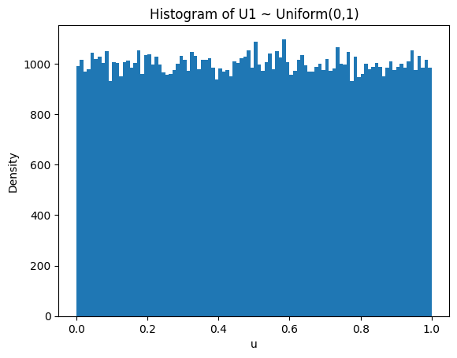

```python
plt.figure()
plt.hist(U1, bins=100)
plt.xlabel("u")
plt.ylabel("Density")
plt.title("Histogram of U1 ~ Uniform(0,1)")
plt.show()
```

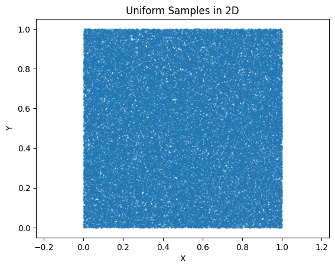

```python
# 2D scatter plot (joint distribution)
plt.figure()
plt.scatter(U1, U2, s=1, alpha=0.4)
plt.xlabel("X")
plt.ylabel("Y")
plt.title("Uniform Samples in 2D")
plt.axis("equal")
plt.show()
```

Indeed, these 100,000 draws looks pretty uniformly distributed to me.

```python
# Box-Muller Transform
Theta = 2 * np.pi * U1
R = np.sqrt(-2 * np.log(U2))
X = R * np.cos(Theta)
Y = R * np.sin(Theta)
```

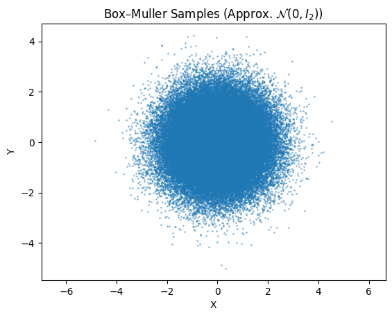

```python
# 2D scatter plot (joint distribution)
plt.figure()
plt.scatter(X, Y, s=1, alpha=0.4)
plt.xlabel("X")
plt.ylabel("Y")
plt.title("Box–Muller Samples (Approx. $\mathcal{N}(0, I_2)$)")
plt.axis("equal")
plt.show()
```

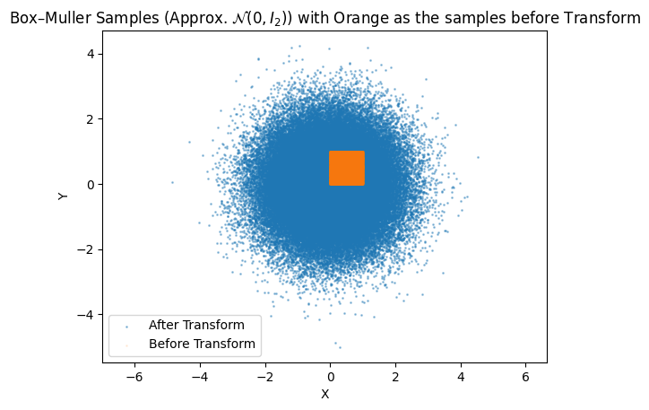

```python
# 2D scatter plot (joint distribution)
plt.figure()
plt.scatter(X, Y, s=1, alpha=0.4)
plt.scatter(U1, U2, s=1, alpha=0.1)
plt.xlabel("X")
plt.ylabel("Y")
plt.legend(["After Transform", "Before Transform"])
plt.title("Box–Muller Samples (Approx. $\mathcal{N}(0, I_2)$) with Orange as the samples before Transform")
plt.axis("equal")
plt.show()
```

The little orange square of uniformly distributed sample points became a symmetrically distributed gaussian blob of points in this 2D cartesian plane, verifying that Box-Muller algorithm is correct, simple, and fast.